# **Отчёт о тестовом задание**

В данном тестовом задание было реализовано и протестировано несколько сверточных нейронных сетей, которые позволяли локализовать и классифицировать мордочку кошки или собаки.

## **Таблица результатов**

```python
import pandas as pd
results = [['ConvNet5', '32%', '32%', '34%', '55%', '58%', '56%', '0.0012'],
              ['ConvNet 2.1', '39%', '39%', '41%', '59%', '63%', '60%', '0.0009'],
              ['MN_1', '74%', '66%', '66%', '99%', '97%', '95%', '0.0083'],
              ['MN_2', '72%', '66%', '67%', '99%', '97%', '96%', '0.0085'],
              ['MN_3', '75%', '66%', '67%', '97%', '91%', '91%', '0.0082']
              ]
df = pd.DataFrame(results, columns=['Название сети','mIoU обучающая','mIoU валидационная','mIoU тестовая', 'Accuracy обучающая','Accuracy валидационная','Accuracy тестовая', 'Скорость'])
df
```

|  | Название сети | mIoU обучающая | mIoU валидационная | mIoU тестовая | Accuracy обучающая | Accuracy валидационная | Accuracy тестовая | Скорость |
| --- | --- | --- | --- | --- | --- | --- | --- | --- |
| 0 | ConvNet5 | 32% | 32% | 34% | 55% | 58% | 56% | 0.0012 |
| 1 | ConvNet 2.1 | 39% | 39% | 41% | 59% | 63% | 60% | 0.0009 |
| 2 | MN_1 | 74% | 66% | 66% | 99% | 97% | 95% | 0.0083 |
| 3 | MN_2 | 72% | 66% | 67% | 99% | 97% | 96% | 0.0085 |
| 4 | MN_3 | 75% | 66% | 67% | 97% | 91% | 91% | 0.0082 |

Валидационная выборка здесь использовалась для изменения learning rate, а также для сравнения моделей между собой. Тестовую выборку я не использовал для оценки качества модели при обучении, результаты на ней я замерил только в самом конце, когда уже выбрал 5 итоговых моделей.

# **Этапы работы**

## **Подтоговка данных**

### **Решение проблемы с дисбалансом классов**

В предложенном датасете для обучения содержалось 1037 изображений кошек и 2348 изображений собак. Здесь сразу же наблюдался явный дизбаланс между классами. И для решения этой проблемы было проведено добавление в датасет аугументированных изображений с кошками.

Так как это не только задача классификации, но и задача локализации, при аугументации изображений нужно также изменять координаты bounding boxes. Для этого мною была выбрана библиотека *imgaug*, которая имеет множество различных аугументаций и позволяет также изменять координаты bounding boxes.

Для того чтобы сбалансировать классы я взял картинки, на которых изображены кошки, и после чего для каждой из них делал одну из 4 случайных трансформаций:

- Поворот на 90 градусов
- Поворот на 180 градусов
- Переворот по вертикали
- Переворот по горизонтали

Были выбраны только простые аугументации, потому что в данном случае она применялась не для усложнения задачи, а для искусственного расширения датасета, чтобы дисбаланс классов был менее существенный.

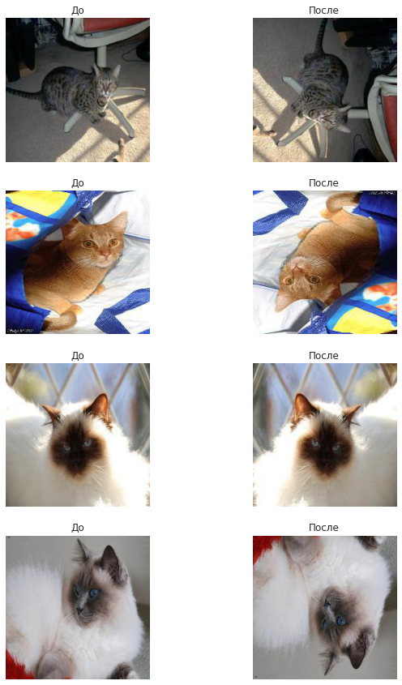

```python
path = '/content/drive/MyDrive/datasets/cats_dogs_220_balanced'
from PIL import Image
import matplotlib.pyplot as plt
import os
images = [Image.open(os.path.join(path,'Bengal_161.jpg')),
          Image.open(os.path.join(path,'Bengal_161_0.jpg')),
          Image.open(os.path.join(path,'Abyssinian_100.jpg')),
          Image.open(os.path.join(path,'Abyssinian_100_1.jpg')),
          Image.open(os.path.join(path,'Birman_12.jpg')),
          Image.open(os.path.join(path,'Birman_12_2.jpg')),
          Image.open(os.path.join(path,'Birman_132.jpg')),
          Image.open(os.path.join(path,'Birman_132_3.jpg'))
          ]
plt.figure(figsize=[10,15])
for i in range(8):
    plt.subplot(4,2,i+1)
    plt.imshow(images[i])
    plt.axis('off')
    if i % 2 == 0:
        plt.title('До')
    else:
        plt.title('После')
```

**Теперь имеется 2074 изображений с кошками и 2348 изображений с собаками.**

### **Разбиение данных на обучающую, валидационную и тестовую выборку**

С помощью функции из scikit-learn **train_test_split** было проведенно разбиение датасета на несколько частей в соотношении 80%/10%/10%. После чего было полученно следующие разделение:

|  | Количество | Тип | Класс |
| --- | --- | --- | --- |
| 0 | 1663 | Обучающая | Кошки |
| 1 | 1874 | Обучающая | Собаки |
| 2 | 212 | Валидационная | Кошки |
| 3 | 230 | Валидационная | Собаки |
| 4 | 199 | Тестовая | Кошки |
| 5 | 244 | Тестовая | Собаки |

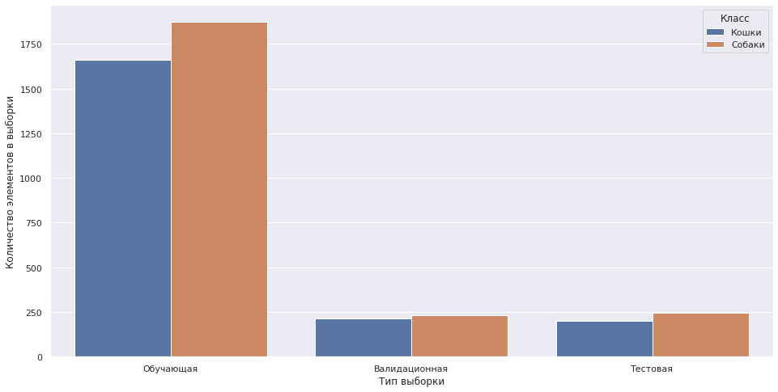

```python
import pandas as pd
import seaborn as sns
import matplotlib.pyplot as plt

sns.set(rc={'figure.figsize':(16,8)})
data = [[1663, 'Обучающая', 'Кошки'],
        [1874, 'Обучающая', 'Собаки'],
        [212, 'Валидационная', 'Кошки'],
        [230, 'Валидационная', 'Собаки'],
        [199, 'Тестовая', 'Кошки'],
        [244, 'Тестовая', 'Собаки']]
df = pd.DataFrame(data, columns=['Количество','Тип','Класс'])
sns.barplot(x='Тип',y='Количество',hue='Класс',data=df)
plt.xlabel('Тип выборки')
plt.ylabel('Количество элементов в выборки')
df
```

Как можно заметить по представленным выше данным, разбиенние датасета на несколько частей получилось довольно сбалансированным. Данное разбиенние получилось при seed = 0.

### **Аугументирование обучающей выборки**

Так как после сбалансировки датасета обучающих данных осталось всё ещё довольно мало, я отдельно аугументировал эту часть датасета. Для каждой картинки из обучающей части я создал ещё одну аугументированную картинку. Я воспользовался той же библиотекой, но использовал более сложные аугументации.

- Случайный поворот от -180 градусов до 180 градусов
- Перспективной искажение

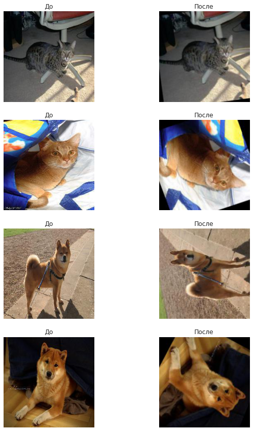

```python
path = '/content/drive/MyDrive/datasets/cats_dogs_220_ext/imgs'

images = [Image.open(os.path.join(path,'Bengal_161.jpg')),
          Image.open(os.path.join(path,'Bengal_161_aug.jpg')),
          Image.open(os.path.join(path,'Abyssinian_100.jpg')),
          Image.open(os.path.join(path,'Abyssinian_100_aug.jpg')),

          Image.open(os.path.join(path,'shiba_inu_143.jpg')),
          Image.open(os.path.join(path,'shiba_inu_143_aug.jpg')),

          Image.open(os.path.join(path,'shiba_inu_107.jpg')),
          Image.open(os.path.join(path,'shiba_inu_107_aug.jpg')),

          ]
plt.figure(figsize=[10,15])
for i in range(8):
    plt.subplot(4,2,i+1)
    plt.imshow(images[i])
    plt.axis('off')
    if i % 2 == 0:
        plt.title('До')
    else:
        plt.title('После')
```

Теперь у меня следующие количество элементов в датасете:

```python
data = [[3326, 'Обучающая', 'Кошки'],
        [3748, 'Обучающая', 'Собаки'],
        [212, 'Валидационная', 'Кошки'],
        [230, 'Валидационная', 'Собаки'],
        [199, 'Тестовая', 'Кошки'],
        [244, 'Тестовая', 'Собаки']]
df = pd.DataFrame(data, columns=['Количество','Тип','Класс'])
df
```

|  | Количество | Тип | Класс |
| --- | --- | --- | --- |
| 0 | 3326 | Обучающая | Кошки |
| 1 | 3748 | Обучающая | Собаки |
| 2 | 212 | Валидационная | Кошки |
| 3 | 230 | Валидационная | Собаки |
| 4 | 199 | Тестовая | Кошки |
| 5 | 244 | Тестовая | Собаки |

```python
print(f'Суммарное количество элементов {df["Количество"].sum()}')
print(f'Суммарное количество элементов в обучающей части {df[df["Тип"] == "Обучающая"]["Количество"].sum()}')
print(f'Суммарное количество элементов в валидационной части {df[df["Тип"] == "Валидационная"]["Количество"].sum()}')
print(f'Суммарное количество элементов в тестовая части {df[df["Тип"] == "Тестовая"]["Количество"].sum()}')
```

```
Суммарное количество элементов 7959
Суммарное количество элементов в обучающей части 7074
Суммарное количество элементов в валидационной части 442
Суммарное количество элементов в тестовая части 443
```

Ниже взяты те части кода, которые необходимы для тестирования модели.

```python
from easydict import EasyDict
import os

cfg = EasyDict()
cfg.random_seed = 0
cfg.device = 'cuda:0'
cfg.save_logs = True
cfg.batch_size = 8
cfg.threshold_classifier = 0.5
cfg.path_to_dataset = '/content/drive/MyDrive/datasets/cats_dogs_220_ext'
cfg.path_to_load = os.path.join('/content/drive/MyDrive','models','mobilenet_big')
cfg.save_models = False
cfg.save_best_model = False
cfg.load_save = True
cfg.name_save = 'best_checkpoint'
```

```python
import os
import torch
from PIL import Image
from sklearn.model_selection import train_test_split
from torch.utils.data import DataLoader
import numpy as np
from torchvision import transforms
from torchsummary import summary
class CatsDogs(torch.utils.data.Dataset):
    def __init__(self, path, cfg, work_mode='train', transform_mode='train'):
        """
        This class is used to create a dataset.
        :param path: path to images and annotations
        :param cfg: config
        :param work_mode:
         @train - the part of the dataset on which the training will take place;
         @valid - the part of the dataset where the selection of hyperparameters and other settings
         @test - the part of the dataset where the final accuracy will be measured
         @full_test - this is a combination of the validation and testing parts, if you don't need separation
        :param transform_mode: for selection augmentation
        """
        self.path_to_dataset = path
        self.path_dir = path + '/imgs'
        self.work_mode = work_mode
        self.transform_mode = transform_mode
        self.cfg = cfg

        self.paths_to_imgs = []
        self.__get_paths_to('.jpg', self.paths_to_imgs)
        self.paths_to_imgs.sort()

        self.paths_to_target = []
        self.__get_paths_to('.txt', self.paths_to_target)
        self.paths_to_target.sort()

        self.nb_classes = 2
        self.nb_samples = 3385

        self.__split_by_file(work_mode)

        self.crop_size = 32
        self.angle_rotation = 30
        self.sz_resize = 220
        self.means = np.array([0.485, 0.456, 0.406])
        self.stds = np.array([0.229, 0.224, 0.225])

    def __get_paths_to(self, ext, paths):
        """
        This function is used to extract paths
        :param ext:
        @.jpg - get paths to images
        @.txt - get paths to annotations
        :param paths: list for storing paths
        """
        for file in os.listdir(self.path_dir):
            if file.endswith(ext):
                paths.append(os.path.join(self.path_dir, file))

    def __split_and_take(self, name_part):
        """
        This function is used to separate and get the training/validation/test part from the dataset
        :param name_part: names of the part to get
        """

        train_x, full_test_x, train_y, full_test_y = train_test_split(self.paths_to_imgs, self.paths_to_target,
                                                                      test_size=0.2, random_state=self.cfg.random_seed)

        if name_part == 'train':
            self.imgs = train_x
            self.target = train_y
        elif name_part == 'valid' or name_part == 'test':
            valid_x, test_x, valid_y, test_y = train_test_split(full_test_x, full_test_y, test_size=0.5,
                                                                random_state=self.cfg.random_seed)
            self.imgs = valid_x if name_part == 'valid' else test_x
            self.target = valid_y if name_part == 'valid' else test_y
        elif name_part == 'full_test':
            self.imgs = full_test_x
            self.target = full_test_y

    def __split_by_file(self, name_part):
        imgs = []
        targets = []
        with open(os.path.join(self.path_to_dataset, f'name_imgs_{name_part}.txt')) as f:
            names_imgs = f.readlines()
        for name in names_imgs:
            imgs.append(name[:-1])
        with open(os.path.join(self.path_to_dataset, f'name_txts_{name_part}.txt')) as f:
            names_targets = f.readlines()
        for target in names_targets :
            targets.append(target[:-1])

        self.imgs = imgs
        self.target = targets


    def split_and_take_from_file(self):
        for name_part in ['train', 'valid','test']:

            with open(os.path.join(self.path_to_dataset, f'{name_part}_name.txt'),'r') as f:
                names = f.readlines()
            for name in names:
                name = name[:-1]
                for name_ in self.paths_to_imgs:
                    if name+'.jpg' in name_ or name+'_aug' in name_:
                        with open(os.path.join(self.path_to_dataset,f'name_imgs_{name_part}.txt'),'a') as f:
                            f.write(name_+'\n')
                        with open(os.path.join(self.path_to_dataset,f'name_txts_{name_part}.txt'),'a') as f:
                            f.write(name_[:-4]+'.txt'+'\n')
    def save_name_files(self, name_part, path):
        train_x, full_test_x, train_y, full_test_y = train_test_split(self.paths_to_imgs, self.paths_to_target,
                                                                      test_size=0.2, random_state=self.cfg.random_seed)

        if name_part == 'train':
            names = train_x
        elif name_part == 'valid' or name_part == 'test':
            valid_x, test_x, valid_y, test_y = train_test_split(full_test_x, full_test_y, test_size=0.5,
                                                                random_state=self.cfg.random_seed)
            names = valid_x if name_part == 'valid' else test_x
        elif name_part == 'full_test':
            names = full_test_x

        with open(os.path.join(path, f'{name_part}_name.txt'), 'a') as f:
            for name in names:
                f.write(name[name.rfind('\\')+2:-4]+'\n')
    def get_labels_classes(self):
        labels = []
        for path_to_file in self.target:
            with open(path_to_file,'r') as f:
                label = int(f.read().split()[0])
            labels.append(label)
        return labels

    def __len__(self):
        return len(self.target)

    def __getitem__(self, idx):
        img = Image.open(self.imgs[idx])
        if len(list(img.split())) != 3:
            img = img.convert('RGB')
        img = self.apply_augmentation(img)
        with open(self.target[idx],'r') as f:
            target = np.array(f.read().split()).astype('int32')
        target[0] -= 1
        return img, torch.Tensor(target)

    def apply_augmentation(self, img):
        transforms_ = transforms.Compose([
            transforms.ToTensor(),
            transforms.Normalize(
                mean=self.means,
                std=self.stds,
            )
        ])
        return transforms_(img)
```

```python
def load_model(load_path, model, cfg, optimizer=None):
    checkpoint = torch.load(load_path)
    load_state_dict = checkpoint['model']
    model_state_dict = model.state_dict()
    for key in model_state_dict:
        if key in load_state_dict:
            model_state_dict[key] = load_state_dict[key]
    model.load_state_dict(model_state_dict)
    start_epoch = checkpoint['epoch'] + 1
    best_score = checkpoint['best_score']
    if optimizer is not None:
        optimizer.load_state_dict(checkpoint['opt'])
        for state in optimizer.state.values():
            for k, v in state.items():
                if isinstance(v, torch.Tensor):
                    state[k] = v.to(cfg.device)
    return model, optimizer, start_epoch, best_score


def evaluate(data_loader, model,  epoch, name_data, cfg, criterion=None):
    print(f'Evaluate {name_data}')
    model.eval()
    accuracy_sum = 0
    iou_sum = 0
    precision_sum = 0
    recall_sum = 0
    total_iter = len(data_loader)
    count_iter = 0
    for iteration, batch in enumerate(data_loader):
        images = batch[0].to(cfg.device)
        targets = batch[1].to(cfg.device)
        count_iter += 1

        with torch.no_grad():
            output = model(images)
            if criterion is not None:
                loss_localization = criterion[0](output[:, 1:], targets[:, 1:])
                loss_classification = criterion[1](output[:, 0], targets[:, 0])
                loss = loss_localization + loss_classification

            convert_coord = output[:, 1:].clone()
            convert_coord[:, [0, 2]] *= images[0].size(1)
            convert_coord[:, [1, 3]] *= images[0].size(2)
            iou = IoU(convert_coord, targets[:, 1:], cfg).item()
            predict = torch.where(output[:, 0] >= cfg.threshold_classifier, 1, 0)

            accuracy = (predict == targets[:, 0]).type(torch.float16).mean().item()

            precision, recall = calc_precision_recall(predict, targets[:, 0])



        precision_sum += precision
        recall_sum += recall
        iou_sum += iou
        accuracy_sum += accuracy

    print(f'mIoU = {iou_sum/ count_iter}; Accuracy = {accuracy_sum/ count_iter}; \n'
          f'Precision = {precision_sum/ count_iter}; Recall = {recall_sum/ count_iter}')



    return  iou_sum / total_iter, accuracy_sum / total_iter


def IoU(prediction_box, ground_truth_box, cfg):
    """
    This function calculates mean Intersection over Union for numpy arrays and torch tensors
    :param prediction_box: coords of prediction boxes [x_left_up, y_left_up, x_right_down, y_right_down]
    :param ground_truth_box: coords of ground truth boxes [x_left_up, y_left_up, x_right_down, y_right_down]
    :return: mean IoU
    """
    if isinstance(prediction_box, torch.Tensor):  # if the torch tensor was passed
        prediction_box = prediction_box.type(torch.int32)
        ground_truth_box = ground_truth_box.type(torch.int32)

        # calculating the intersection area
        x_left_up = torch.max(prediction_box[:, 0], ground_truth_box[:, 0])
        y_left_up = torch.max(prediction_box[:, 1], ground_truth_box[:, 1])
        x_right_down = torch.min(prediction_box[:, 2], ground_truth_box[:, 2])
        y_right_down = torch.min(prediction_box[:, 3], ground_truth_box[:, 3])
        zero = torch.Tensor([0]).to(cfg.device)
        intersection = torch.max(zero, x_right_down - x_left_up + 1) * \
                       torch.max(zero, y_right_down - y_left_up + 1)
    elif isinstance(prediction_box, np.ndarray):  # if the numpy array was passed
        prediction_box = prediction_box.astype(np.int32)
        ground_truth_box = ground_truth_box.astype(np.int32)

        # calculating the intersection area
        x_left_up = np.maximum(prediction_box[:, 0], ground_truth_box[:, 0])
        y_left_up = np.maximum(prediction_box[:, 1], ground_truth_box[:, 1])
        x_right_down = np.minimum(prediction_box[:, 2], ground_truth_box[:, 2])
        y_right_down = np.minimum(prediction_box[:, 3], ground_truth_box[:, 3])
        intersection = np.maximum(0, x_right_down - x_left_up + 1) * np.maximum(0, y_right_down - y_left_up + 1)

    # calculating the union area
    square_p_box = (prediction_box[:, 2] - prediction_box[:, 0] + 1) * (prediction_box[:, 3] - prediction_box[:, 1] + 1)
    square_gt_box = (ground_truth_box[:, 2] - ground_truth_box[:, 0] + 1) \
                    * (ground_truth_box[:, 3] - ground_truth_box[:, 1] + 1)
    union = (square_p_box + square_gt_box - intersection)

    mean_iou = (intersection / union).mean()
    return mean_iou


def calc_precision_recall(predict, ground_truth):
    correct_predict = predict == ground_truth

    true_positive = torch.logical_and(correct_predict == True, ground_truth == 1)
    false_positive = torch.logical_and(correct_predict == False, ground_truth == 0)
    false_negative = torch.logical_and(correct_predict == False, ground_truth == 1)

    temp1 = (true_positive + false_positive).sum().item()
    temp2 = (true_positive + false_negative).sum().item()

    precision = true_positive.sum().item()/temp1 if temp1 != 0 else 1
    recall = true_positive.sum().item()/temp2 if temp2 != 0 else 1


    return precision, recall

def test(dataset, model, cfg):
    if cfg.load_save:
        model, optimizer, start_epoch, best_score = load_model(os.path.join(cfg.path_to_load,cfg.name_save),
                                                                 model,
                                                                 cfg,
                                                                 None)
    dl_test = DataLoader(dataset, batch_size=cfg.batch_size, shuffle=True)
    evaluate(dl_test, model,  start_epoch, dataset.work_mode, cfg)
```

```python
ds_train = CatsDogs(cfg.path_to_dataset, cfg, work_mode='train')
ds_valid = CatsDogs(cfg.path_to_dataset, cfg, work_mode='valid')
ds_test = CatsDogs(cfg.path_to_dataset, cfg, work_mode='test')
```

## **Создание собственной сверточной нейронной сети**

Мною были испробаваны различные модели. В данный отчёт я вынесу только две из них, потому что другие модели это по факту не улучшенные версии представленных, но о них тоже будет рассказано.

### **I. Модели типа Conv -> ReLU -> MaxPool (ConvNet5)**

Изначально я попробовал сделать модель, которая состояла только из сверточных слоёв, и в конце добавлялся полносвязный. Потом я добавил между сверточными слоями pooling слой. Далее между сверточным слоём и pooling слоём был добавлен слой активации. А в следующий версии был добавлен также dropout. Проблемной всех этих моделей был достаточно быстрой переход к переобучению. Итоговый вариант имеет следующую архитектуру:

```python
class ConvNetV5(nn.Module):
    def __init__(self, nb_outs=5):
        super(ConvNetV5, self).__init__()
        self.nb_outs = nb_outs

        self.conv1 = nn.Conv2d(3, 16, 21)
        self.conv2 = nn.Conv2d(16, 32, 11)
        self.conv3 = nn.Conv2d(32, 64, 6)
        self.conv4 = nn.Conv2d(64, 128, 5)
        self.conv5 = nn.Conv2d(128, 256, 5)
        # self.dense1 = nn.Linear(4096, 1024)
        self.linear_localize = torch.nn.Linear(1024, 4)
        self.linear_classify = torch.nn.Linear(1024, 1)
        self.flatten = nn.Flatten()
        self.pool = nn.MaxPool2d(2, 2)
        self.relu = nn.ReLU()
        self.dropout_p_0_5 = nn.Dropout(0.5)
        self.dropout_p_0_2 = nn.Dropout(0.2)

    def forward(self, input):
        x = self.relu(self.conv1(input))
        x = self.dropout_p_0_2(x)
        x = self.pool(x)
        x = self.relu(self.conv2(x))
        x - self.dropout_p_0_2(x)
        x = self.pool(x)
        x = self.relu(self.conv3(x))
        x = self.dropout_p_0_2(x)
        x = self.pool(x)
        x = self.relu(self.conv4(x))
        x = self.dropout_p_0_2(x)
        x = self.pool(x)
        x = self.relu(self.conv5(x))
        x = self.dropout_p_0_2(x)
        x = self.pool(x)
        x = self.flatten(x)
        # x = self.dense1(x)
        # x = self.dropout_p_0_5(x)
        coords = self.linear_localize(x)
        classes = self.linear_classify(x)
        return torch.cat((classes, coords),axis=1)
```

```python
cfg.path_to_load = os.path.join('/content/drive/MyDrive','models','convnet_5')
model = ConvNetV5().cuda()
summary(model,(3,220,220))
test(ds_train,model,cfg)
test(ds_valid,model,cfg)
test(ds_test,model,cfg)
```

```
----------------------------------------------------------------
        Layer (type)               Output Shape         Param #
================================================================
            Conv2d-1         [-1, 16, 200, 200]          21,184
              ReLU-2         [-1, 16, 200, 200]               0
           Dropout-3         [-1, 16, 200, 200]               0
         MaxPool2d-4         [-1, 16, 100, 100]               0
            Conv2d-5           [-1, 32, 90, 90]          61,984
              ReLU-6           [-1, 32, 90, 90]               0
           Dropout-7           [-1, 32, 90, 90]               0
         MaxPool2d-8           [-1, 32, 45, 45]               0
            Conv2d-9           [-1, 64, 40, 40]          73,792
             ReLU-10           [-1, 64, 40, 40]               0
          Dropout-11           [-1, 64, 40, 40]               0
        MaxPool2d-12           [-1, 64, 20, 20]               0
           Conv2d-13          [-1, 128, 16, 16]         204,928
             ReLU-14          [-1, 128, 16, 16]               0
          Dropout-15          [-1, 128, 16, 16]               0
        MaxPool2d-16            [-1, 128, 8, 8]               0
           Conv2d-17            [-1, 256, 4, 4]         819,456
             ReLU-18            [-1, 256, 4, 4]               0
          Dropout-19            [-1, 256, 4, 4]               0
        MaxPool2d-20            [-1, 256, 2, 2]               0
          Flatten-21                 [-1, 1024]               0
           Linear-22                    [-1, 4]           4,100
           Linear-23                    [-1, 1]           1,025
================================================================
Total params: 1,186,469
Trainable params: 1,186,469
Non-trainable params: 0
----------------------------------------------------------------
Input size (MB): 0.55
Forward/backward pass size (MB): 25.76
Params size (MB): 4.53
Estimated Total Size (MB): 30.84
----------------------------------------------------------------
Evaluate train
mIoU = 0.32110725732537004; Accuracy = 0.5547578828828829;
Precision = 0.9662537537537538; Recall = 0.1643035387661178
Evaluate valid
mIoU = 0.32657367842538015; Accuracy = 0.5875767299107143;
Precision = 1.0; Recall = 0.20771174713291032
Evaluate test
mIoU = 0.3427136689424515; Accuracy = 0.5650460379464286;
Precision = 0.9821428571428571; Recall = 0.21742532738773337
```

### **II. Модель типа Conv -> ReLU -> Conv -> ReLU -> MaxPool (ConvNet 2.1)**

Далее был совершен переход к модели, где pooling слой идёт после пары сверточных слоёв с активацией.

```python
from torch import nn
import torch

class ConvNetV2_1(nn.Module):
    def __init__(self):
        super(ConvNetV2_1, self).__init__()

        self.conv1 = nn.Conv2d(3, 8, 41, stride=2) # 90
        self.conv2 = nn.Conv2d(8, 8, 19, stride=2) # 36
        self.conv3 = nn.Conv2d(8, 16, 3) # 16
        self.conv4 = nn.Conv2d(16, 16, 3) # 14
        self.dense1 = nn.Linear(784, 512)
        self.linear_localize = nn.Linear(512, 4)
        self.linear_classify = nn.Linear(512, 1)
        self.flatten = nn.Flatten()
        self.pool = nn.MaxPool2d(2, 2)
        self.relu = nn.ReLU()
        self.dropout_p_0_5 = nn.Dropout(0.5)
        self.dropout_p_0_2 = nn.Dropout(0.2)

    def forward(self, input):
        x = self.relu(self.conv1(input))
        x = self.relu(self.conv2(x))
        x = self.pool(x)
        x = self.dropout_p_0_2(x)

        x = self.relu(self.conv3(x))
        x = self.relu(self.conv4(x))
        x = self.pool(x)
        x = self.dropout_p_0_2(x)

        x = self.flatten(x)

        x = self.dense1(x)
        x = self.dropout_p_0_5(x)
        coords = self.linear_localize(x)
        classes = self.linear_classify(x)
        return torch.cat((classes, coords),axis=1)
```

```python
cfg.path_to_load = os.path.join('/content/drive/MyDrive','models','convnet_2_1')
model = ConvNetV2_1().cuda()
summary(model,(3,220,220))
test(ds_train,model,cfg)
test(ds_valid,model,cfg)
test(ds_test,model,cfg)
```

```
----------------------------------------------------------------
        Layer (type)               Output Shape         Param #
================================================================
            Conv2d-1            [-1, 8, 90, 90]          40,352
              ReLU-2            [-1, 8, 90, 90]               0
            Conv2d-3            [-1, 8, 36, 36]          23,112
              ReLU-4            [-1, 8, 36, 36]               0
         MaxPool2d-5            [-1, 8, 18, 18]               0
           Dropout-6            [-1, 8, 18, 18]               0
            Conv2d-7           [-1, 16, 16, 16]           1,168
              ReLU-8           [-1, 16, 16, 16]               0
            Conv2d-9           [-1, 16, 14, 14]           2,320
             ReLU-10           [-1, 16, 14, 14]               0
        MaxPool2d-11             [-1, 16, 7, 7]               0
          Dropout-12             [-1, 16, 7, 7]               0
          Flatten-13                  [-1, 784]               0
           Linear-14                  [-1, 512]         401,920
          Dropout-15                  [-1, 512]               0
           Linear-16                    [-1, 4]           2,052
           Linear-17                    [-1, 1]             513
================================================================
Total params: 471,437
Trainable params: 471,437
Non-trainable params: 0
----------------------------------------------------------------
Input size (MB): 0.55
Forward/backward pass size (MB): 1.32
Params size (MB): 1.80
Estimated Total Size (MB): 3.67
----------------------------------------------------------------
Evaluate train
mIoU = 0.3961025195884275; Accuracy = 0.5926238738738738;
Precision = 0.8553261053261055; Recall = 0.278879836025818
Evaluate valid
mIoU = 0.3920936563185283; Accuracy = 0.623291015625;
Precision = 0.8636621315192744; Recall = 0.34165653440863525
Evaluate test
mIoU = 0.41073890030384064; Accuracy = 0.6060616629464286;
Precision = 0.8700680272108844; Recall = 0.3429717096015194
```

## **Transfer learning**

Для подхода с Transfer learning в роли backbone была выбрана сверточная нейронная сеть MobileNetV3.

### **I. Добавление после AveragePooling одного полносвязнного слоя (MN_1)**

Из backbone было взято две части features блок и avgpool блок. Далее был добавлен один полносвязный слой с 576 входами и 5 выходами.

```python
from torchvision.models import mobilenet_v3_small
from torchsummary import summary
import torch

class ConvNet_w_MN_small_1(torch.nn.Module):
    def __init__(self):
        super(ConvNet_w_MN_small_1, self).__init__()
        mobile_net = mobilenet_v3_small(pretrained=True)
        self.features = mobile_net.features
        self.avgpool = mobile_net.avgpool
        self.linear_localize = torch.nn.Linear(576, 4)
        self.linear_classify = torch.nn.Linear(576, 1)

    def forward(self, input):
        x = self.features(input)
        x = self.avgpool(x)
        x = x.view(input.size(0),-1)
        coords = self.linear_localize(x)
        classes = self.linear_classify(x)
        return torch.cat((classes, coords),axis=1)
```

```python
cfg.path_to_load = os.path.join('/content/drive/MyDrive','models','mobilenet_small')
model = ConvNet_w_MN_small_1().cuda()
summary(model,(3,220,220))
test(ds_train,model,cfg)
test(ds_valid,model,cfg)
test(ds_test,model,cfg)
```

```
----------------------------------------------------------------
        Layer (type)               Output Shape         Param #
================================================================
            Conv2d-1         [-1, 16, 110, 110]             432
       BatchNorm2d-2         [-1, 16, 110, 110]              32
         Hardswish-3         [-1, 16, 110, 110]               0
            Conv2d-4           [-1, 16, 55, 55]             144
       BatchNorm2d-5           [-1, 16, 55, 55]              32
              ReLU-6           [-1, 16, 55, 55]               0
            Conv2d-7              [-1, 8, 1, 1]             136
              ReLU-8              [-1, 8, 1, 1]               0
            Conv2d-9             [-1, 16, 1, 1]             144
SqueezeExcitation-10           [-1, 16, 55, 55]               0
           Conv2d-11           [-1, 16, 55, 55]             256
      BatchNorm2d-12           [-1, 16, 55, 55]              32
         Identity-13           [-1, 16, 55, 55]               0
 InvertedResidual-14           [-1, 16, 55, 55]               0
           Conv2d-15           [-1, 72, 55, 55]           1,152
      BatchNorm2d-16           [-1, 72, 55, 55]             144
             ReLU-17           [-1, 72, 55, 55]               0
           Conv2d-18           [-1, 72, 28, 28]             648
      BatchNorm2d-19           [-1, 72, 28, 28]             144
             ReLU-20           [-1, 72, 28, 28]               0
           Conv2d-21           [-1, 24, 28, 28]           1,728
      BatchNorm2d-22           [-1, 24, 28, 28]              48
         Identity-23           [-1, 24, 28, 28]               0
 InvertedResidual-24           [-1, 24, 28, 28]               0
           Conv2d-25           [-1, 88, 28, 28]           2,112
      BatchNorm2d-26           [-1, 88, 28, 28]             176
             ReLU-27           [-1, 88, 28, 28]               0
           Conv2d-28           [-1, 88, 28, 28]             792
      BatchNorm2d-29           [-1, 88, 28, 28]             176
             ReLU-30           [-1, 88, 28, 28]               0
           Conv2d-31           [-1, 24, 28, 28]           2,112
      BatchNorm2d-32           [-1, 24, 28, 28]              48
         Identity-33           [-1, 24, 28, 28]               0
 InvertedResidual-34           [-1, 24, 28, 28]               0
           Conv2d-35           [-1, 96, 28, 28]           2,304
      BatchNorm2d-36           [-1, 96, 28, 28]             192
        Hardswish-37           [-1, 96, 28, 28]               0
```

[output cut: 119 more lines]

```
----------------------------------------------------------------
Input size (MB): 0.55
Forward/backward pass size (MB): 35.19
Params size (MB): 3.55
Estimated Total Size (MB): 39.29
----------------------------------------------------------------
Evaluate train
mIoU = 0.7490435290980983; Accuracy = 0.9976069819819819;
Precision = 0.9986757679549441; Recall = 0.9972538981826907
Evaluate valid
mIoU = 0.6652040013245174; Accuracy = 0.9732142857142857;
Precision = 0.9765948045885021; Recall = 0.9763321995464853
Evaluate test
mIoU = 0.6628217058522361; Accuracy = 0.9598214285714286;
Precision = 0.9463756555253682; Recall = 0.977682976024418
```

### **II. Добавление двух полносвязных слоёв (MN_2)**

Данный эксперимент аналогичен эксперименту I,но здесь между pooling слоем и последним полносвязным слоём был добавлен ещё один с 576 входами и 2048 выходами, далее идёт последний полносвязный слой с 2048 входами и 5 выходами.

```python
from torchvision.models import mobilenet_v3_small
from torchsummary import summary
import torch

class ConvNet_w_MN_small_v2(torch.nn.Module):
    def __init__(self):
        super(ConvNet_w_MN_small_v2, self).__init__()
        mobile_net = mobilenet_v3_small(pretrained=True)
        self.features = mobile_net.features
        self.avgpool = mobile_net.avgpool
        self.linear1 = torch.nn.Linear(576, 2048)
        self.linear_localize = torch.nn.Linear(2048, 4)
        self.linear_classify = torch.nn.Linear(2048, 1)

    def forward(self, input):
        x = self.features(input)
        x = self.avgpool(x)
        x = x.view(input.size(0),-1)
        x = self.linear1(x)
        coords = self.linear_localize(x)
        classes = self.linear_classify(x)
        return torch.cat((classes, coords),axis=1)
```

```python
cfg.path_to_load = os.path.join('/content/drive/MyDrive','models','mobilenet_mid')
model = ConvNet_w_MN_small_v2().cuda()
summary(model,(3,220,220))
test(ds_train,model,cfg)
test(ds_valid,model,cfg)
test(ds_test,model,cfg)
```

```
----------------------------------------------------------------
        Layer (type)               Output Shape         Param #
================================================================
            Conv2d-1         [-1, 16, 110, 110]             432
       BatchNorm2d-2         [-1, 16, 110, 110]              32
         Hardswish-3         [-1, 16, 110, 110]               0
            Conv2d-4           [-1, 16, 55, 55]             144
       BatchNorm2d-5           [-1, 16, 55, 55]              32
              ReLU-6           [-1, 16, 55, 55]               0
            Conv2d-7              [-1, 8, 1, 1]             136
              ReLU-8              [-1, 8, 1, 1]               0
            Conv2d-9             [-1, 16, 1, 1]             144
SqueezeExcitation-10           [-1, 16, 55, 55]               0
           Conv2d-11           [-1, 16, 55, 55]             256
      BatchNorm2d-12           [-1, 16, 55, 55]              32
         Identity-13           [-1, 16, 55, 55]               0
 InvertedResidual-14           [-1, 16, 55, 55]               0
           Conv2d-15           [-1, 72, 55, 55]           1,152
      BatchNorm2d-16           [-1, 72, 55, 55]             144
             ReLU-17           [-1, 72, 55, 55]               0
           Conv2d-18           [-1, 72, 28, 28]             648
      BatchNorm2d-19           [-1, 72, 28, 28]             144
             ReLU-20           [-1, 72, 28, 28]               0
           Conv2d-21           [-1, 24, 28, 28]           1,728
      BatchNorm2d-22           [-1, 24, 28, 28]              48
         Identity-23           [-1, 24, 28, 28]               0
 InvertedResidual-24           [-1, 24, 28, 28]               0
           Conv2d-25           [-1, 88, 28, 28]           2,112
      BatchNorm2d-26           [-1, 88, 28, 28]             176
             ReLU-27           [-1, 88, 28, 28]               0
           Conv2d-28           [-1, 88, 28, 28]             792
      BatchNorm2d-29           [-1, 88, 28, 28]             176
             ReLU-30           [-1, 88, 28, 28]               0
           Conv2d-31           [-1, 24, 28, 28]           2,112
      BatchNorm2d-32           [-1, 24, 28, 28]              48
         Identity-33           [-1, 24, 28, 28]               0
 InvertedResidual-34           [-1, 24, 28, 28]               0
           Conv2d-35           [-1, 96, 28, 28]           2,304
      BatchNorm2d-36           [-1, 96, 28, 28]             192
        Hardswish-37           [-1, 96, 28, 28]               0
```

[output cut: 120 more lines]

```
----------------------------------------------------------------
Input size (MB): 0.55
Forward/backward pass size (MB): 35.21
Params size (MB): 8.08
Estimated Total Size (MB): 43.84
----------------------------------------------------------------
Evaluate train
mIoU = 0.727244410428915; Accuracy = 0.9956362612612613;
Precision = 0.9951798063707473; Recall = 0.9967545674395517
Evaluate valid
mIoU = 0.6607557237148285; Accuracy = 0.9726911272321429;
Precision = 0.9835609243697478; Recall = 0.9662485448724946
Evaluate test
mIoU = 0.6700706098760877; Accuracy = 0.9642857142857143;
Precision = 0.9572516406881734; Recall = 0.9809278097203794
```

### **III. Увелечение параметров в предпоследним полносвязном слоё (MN_3)**

В данном эксперименте был увеличенно количество параметров в предпоследнем полносвязнном слое, теперь выходе 8192 стало нейронов, а на входе в последний полносвязный 8192 нейрона и выходы всё также 5.

```python
from torchvision.models import mobilenet_v3_small
from torchsummary import summary
import torch

class ConvNet_w_MN_small_v3(torch.nn.Module):
    def __init__(self, nb_outs=5):
        super(ConvNet_w_MN_small_v3, self).__init__()
        mobile_net = mobilenet_v3_small(pretrained=True)
        self.features = mobile_net.features
        self.avgpool = mobile_net.avgpool
        self.linear1 = torch.nn.Linear(576, 8192)#8192
        self.linear_localize = torch.nn.Linear(8192, 4)
        self.linear_classify = torch.nn.Linear(8192, 1)

    def forward(self, input):
        x = self.features(input)
        x = self.avgpool(x)
        x = x.view(input.size(0),-1)
        x = self.linear1(x)
        coords = self.linear_localize(x)
        classes = self.linear_classify(x)
        return torch.cat((classes, coords),axis=1)
```

```python
cfg.path_to_load = os.path.join('/content/drive/MyDrive','models','mobilenet_big')
ds_train = CatsDogs(cfg.path_to_dataset, cfg, work_mode='train')
ds_valid = CatsDogs(cfg.path_to_dataset, cfg, work_mode='valid')
ds_test = CatsDogs(cfg.path_to_dataset, cfg, work_mode='test')
model = ConvNet_w_MN_small_v3().cuda()
summary(model,(3,220,220))
test(ds_train,model,cfg)
test(ds_valid,model,cfg)
test(ds_test,model,cfg)
```

```
----------------------------------------------------------------
        Layer (type)               Output Shape         Param #
================================================================
            Conv2d-1         [-1, 16, 110, 110]             432
       BatchNorm2d-2         [-1, 16, 110, 110]              32
         Hardswish-3         [-1, 16, 110, 110]               0
            Conv2d-4           [-1, 16, 55, 55]             144
       BatchNorm2d-5           [-1, 16, 55, 55]              32
              ReLU-6           [-1, 16, 55, 55]               0
            Conv2d-7              [-1, 8, 1, 1]             136
              ReLU-8              [-1, 8, 1, 1]               0
            Conv2d-9             [-1, 16, 1, 1]             144
SqueezeExcitation-10           [-1, 16, 55, 55]               0
           Conv2d-11           [-1, 16, 55, 55]             256
      BatchNorm2d-12           [-1, 16, 55, 55]              32
         Identity-13           [-1, 16, 55, 55]               0
 InvertedResidual-14           [-1, 16, 55, 55]               0
           Conv2d-15           [-1, 72, 55, 55]           1,152
      BatchNorm2d-16           [-1, 72, 55, 55]             144
             ReLU-17           [-1, 72, 55, 55]               0
           Conv2d-18           [-1, 72, 28, 28]             648
      BatchNorm2d-19           [-1, 72, 28, 28]             144
             ReLU-20           [-1, 72, 28, 28]               0
           Conv2d-21           [-1, 24, 28, 28]           1,728
      BatchNorm2d-22           [-1, 24, 28, 28]              48
         Identity-23           [-1, 24, 28, 28]               0
 InvertedResidual-24           [-1, 24, 28, 28]               0
           Conv2d-25           [-1, 88, 28, 28]           2,112
      BatchNorm2d-26           [-1, 88, 28, 28]             176
             ReLU-27           [-1, 88, 28, 28]               0
           Conv2d-28           [-1, 88, 28, 28]             792
      BatchNorm2d-29           [-1, 88, 28, 28]             176
             ReLU-30           [-1, 88, 28, 28]               0
           Conv2d-31           [-1, 24, 28, 28]           2,112
      BatchNorm2d-32           [-1, 24, 28, 28]              48
         Identity-33           [-1, 24, 28, 28]               0
 InvertedResidual-34           [-1, 24, 28, 28]               0
           Conv2d-35           [-1, 96, 28, 28]           2,304
      BatchNorm2d-36           [-1, 96, 28, 28]             192
        Hardswish-37           [-1, 96, 28, 28]               0
```

[output cut: 120 more lines]

```
----------------------------------------------------------------
Input size (MB): 0.55
Forward/backward pass size (MB): 35.25
Params size (MB): 21.72
Estimated Total Size (MB): 57.53
----------------------------------------------------------------
Evaluate train
mIoU = 0.752233529681558; Accuracy = 0.9725506756756757;
Precision = 0.9719745495674292; Recall = 0.977005632050053
Evaluate valid
mIoU = 0.669571999992643; Accuracy = 0.9114118303571429;
Precision = 0.9024568059342497; Recall = 0.9207212169618185
Evaluate test
mIoU = 0.6777805941445487; Accuracy = 0.9180036272321429;
Precision = 0.9236507322227138; Recall = 0.9315656086996202
```

## **Замер скорости инференса**

```python
cfg.batch_size = 1
```

Добавляем замер времени в функцию оценки

```python
import time
def evaluate(data_loader, model,  epoch, name_data, cfg, criterion=None):
    print(f'Evaluate {name_data}')
    model.eval()
    accuracy_sum = 0
    iou_sum = 0
    precision_sum = 0
    recall_sum = 0
    total_iter = len(data_loader)
    count_iter = 0
    time_inference = 0
    for iteration, batch in enumerate(data_loader):
        images = batch[0].to(cfg.device)
        targets = batch[1].to(cfg.device)
        count_iter += 1

        with torch.no_grad():
            s = time.time()
            output = model(images)
            time_inference += time.time() - s
            if criterion is not None:
                loss_localization = criterion[0](output[:, 1:], targets[:, 1:])
                loss_classification = criterion[1](output[:, 0], targets[:, 0])
                loss = loss_localization + loss_classification

            convert_coord = output[:, 1:].clone()
            convert_coord[:, [0, 2]] *= images[0].size(1)
            convert_coord[:, [1, 3]] *= images[0].size(2)
            iou = IoU(convert_coord, targets[:, 1:], cfg).item()
            predict = torch.where(output[:, 0] >= cfg.threshold_classifier, 1, 0)

            accuracy = (predict == targets[:, 0]).type(torch.float16).mean().item()

            precision, recall = calc_precision_recall(predict, targets[:, 0])



        precision_sum += precision
        recall_sum += recall
        iou_sum += iou
        accuracy_sum += accuracy

    print(f'mIoU = {iou_sum/ count_iter}; Accuracy = {accuracy_sum/ count_iter}; \n'
          f'Precision = {precision_sum/ count_iter}; Recall = {recall_sum/ count_iter}; Infrence time={time_inference/count_iter}')



    return  iou_sum / total_iter, accuracy_sum / total_iter
```

```python
cfg.path_to_load = os.path.join('/content/drive/MyDrive','models','convnet_5')
model = ConvNetV5().cuda()
test(ds_test,model,cfg)
```

```
Evaluate test
mIoU = 0.34238341630569974; Accuracy = 0.5643340857787811;
Precision = 0.9977426636568849; Recall = 0.5665914221218962; Infrence time=0.0012809492933561785
```

```python
cfg.path_to_load = os.path.join('/content/drive/MyDrive','models','convnet_2_1')
model = ConvNetV2_1().cuda()
test(ds_test,model,cfg)
```

```
Evaluate test
mIoU = 0.41029020411258826; Accuracy = 0.6049661399548533;
Precision = 0.9683972911963883; Recall = 0.636568848758465; Infrence time=0.0009733543439051367
```

```python
cfg.path_to_load = os.path.join('/content/drive/MyDrive','models','mobilenet_small')
model = ConvNet_w_MN_small_1().cuda()
test(ds_test,model,cfg)
```

```
Evaluate test
mIoU = 0.662143783638586; Accuracy = 0.9593679458239278;
Precision = 0.9706546275395034; Recall = 0.9887133182844243; Infrence time=0.008382594343232786
```

```python
cfg.path_to_load = os.path.join('/content/drive/MyDrive','models','mobilenet_mid')
model = ConvNet_w_MN_small_v2().cuda()
test(ds_test,model,cfg)
```

```
Evaluate test
mIoU = 0.6695404293995275; Accuracy = 0.963882618510158;
Precision = 0.9751693002257337; Recall = 0.9887133182844243; Infrence time=0.008519715703098823
```

```python
cfg.path_to_load = os.path.join('/content/drive/MyDrive','models','mobilenet_big')
model = ConvNet_w_MN_small_v3().cuda()
test(ds_test,model,cfg)
```

```
Evaluate test
mIoU = 0.6782510506144764; Accuracy = 0.9187358916478555;
Precision = 0.9571106094808126; Recall = 0.9616252821670429; Infrence time=0.00828085473105816
```

## **Дополнительное**

### 1. Реализация нейронной сети на NumPy

Запустить модель и обучить её, я не успел из-за того, что не хватало времени на отладку и последующие обучение. Но я реализовал на NumPy такие слои как Conv2d, Pooling, Dropout, Flatten, Activations Layers, Linear. Они все были протестированы как для forward pass, так и backward pass. Результаты вычислений сравнивались с тем как считал PyTorch. Коды для всего что касатается этого лежат в репозиторие NNumpy

### 2. Попытка обучить модели поэтапно.

Я эксперементировал с тем, чтобы к примеру сначала модель обучить только на задачу классификации, то есть не считать градиенты для нейронов участвующих в локализации, а потом заморозить всю нейронную сеть кроме той части, которая отвечала за локализацию в последнем линейном слое. Также я пробовал поступить наоборот то есть сначала локализовать, а потом классифицировать. Но интересных результатов это не дало.